# 02 Sentiment analysis with tidy data

H. David Shea

29 Jul 2021

**Opinion mining** or **sentiment analysis** refers to determining the emotional intent of words - whether the text is positive or negative, say. The following examples show the use of text mining tools to “approach the emotional content of text programmatically.”

## The `sentiments` datasets

The `tidytext` package provides access to several sentiment lexicons. These are accessible via the `get_sentiments()` function.

```r
kable(get_sentiments("afinn")[1:10,])
```

| word | value |
| --- | --- |
| abandon | -2 |
| abandoned | -2 |
| abandons | -2 |
| abducted | -2 |
| abduction | -2 |
| abductions | -2 |
| abhor | -3 |
| abhorred | -3 |
| abhorrent | -3 |
| abhors | -3 |

```r
kable(get_sentiments("bing")[1:10,])
```

| word | sentiment |
| --- | --- |
| 2-faces | negative |
| abnormal | negative |
| abolish | negative |
| abominable | negative |
| abominably | negative |
| abominate | negative |
| abomination | negative |
| abort | negative |
| aborted | negative |
| aborts | negative |

```r
kable(get_sentiments("nrc")[1:10,])
```

| word | sentiment |
| --- | --- |
| abacus | trust |
| abandon | fear |
| abandon | negative |
| abandon | sadness |
| abandoned | anger |
| abandoned | fear |
| abandoned | negative |
| abandoned | sadness |
| abandonment | anger |
| abandonment | fear |

“Dictionary-based methods like the ones we are discussing find the total sentiment of a piece of text by adding up the individual sentiment scores for each word in the text.”

Some limitations of this approach:

- must be sure that the lexicon and the text being analyzed are similar in style and time reference
- qualifier words - like ‘not’ in ‘not happy’ - are treated separately from their qualified term
- in narrative context, concepts like sarcasm and irony will not be captured
- the size of the analyzed text can complicate things if the sentiment changes in different sections of the text

## Sentiment analysis with inner join

Here we will use the `nrc` lexicon and filter words that connotate ‘joy’. Doing an `inner_join()` of the book text with these ‘joy’ words, we can determine how often the ‘joy’ words appeared in the text.

NOTE: for these analyses, we will not remove any stop words as words like ‘good’ are included in them.

```r
tidy_books <- austen_books() %>%
    group_by(book) %>%
    mutate(linenumber = row_number(),
           chapter = cumsum(str_detect(
               text,
               regex("^chapter [\\divxlc]",
                     ignore_case = TRUE)
           ))) %>%
    ungroup() %>%
    unnest_tokens(word, text)

nrc_joy <- get_sentiments("nrc") %>%
    filter(sentiment == "joy")

tidy_books %>%
    filter(book == "Emma") %>%
    inner_join(nrc_joy, by = "word") %>%
    count(word, sort = TRUE) %>%
    filter(n >= 80) %>%
    kable()
```

| word | n |
| --- | --- |
| good | 359 |
| young | 192 |
| friend | 166 |
| hope | 143 |
| happy | 125 |
| love | 117 |
| deal | 92 |
| found | 92 |
| present | 89 |
| kind | 82 |

Next, we track the change in sentiment through the Jane Austen books. This is done by joining the words to the `bing` lexicon which denotes words as either negative or positive. Then each book is broken up into consecutive 80 line chunks (see `index` in the `count` below). For each 80 line chunk, calculate `sentiment` as the number of `positive` words minus the number of `negative` words. Then plot the `sentiment` versus `index` for each book.

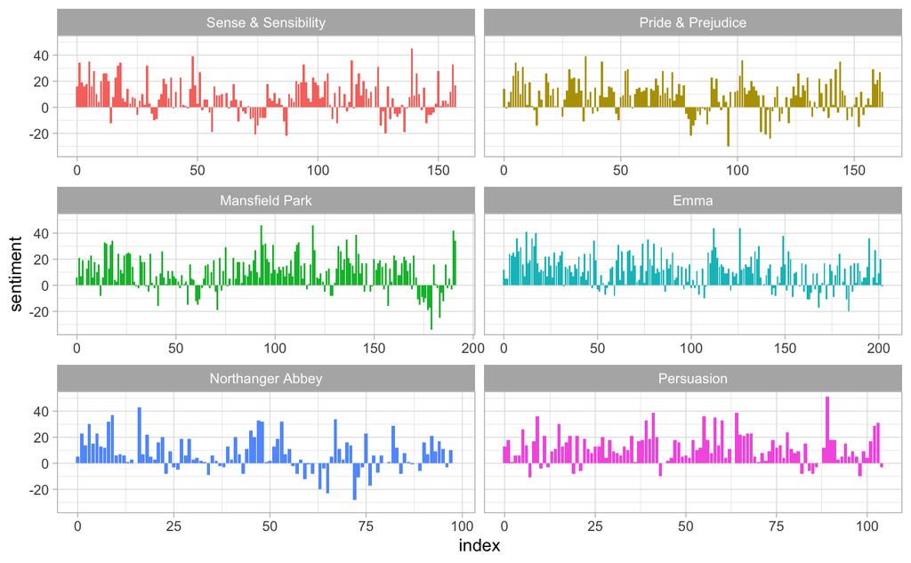

```r
jane_austen_sentiment <- tidy_books %>%
    inner_join(get_sentiments("bing"), by = "word") %>%
    count(book, index = linenumber %/% 80, sentiment) %>%
    pivot_wider(names_from = sentiment,
                values_from = n,
                values_fill = 0) %>%
    mutate(sentiment = positive - negative)

ggplot(jane_austen_sentiment, aes(index, sentiment, fill = book)) +
    geom_col(show.legend = FALSE) +
    facet_wrap( ~ book, ncol = 2, scales = "free_x") +
    theme_light()
```

## Comparing the three sentiment dictionaries

The three sentiment lexicons that we have reviewed all have variations in the way they sourced their sentimeent indications. And, the `afinn` lexicon uses a `-5` to `+5` scale for sentiment rather than the binary `negative` or `positive` indicators used by then `bing` and `nrc` lexicons. Nonetheless, with a little work, we can compare the sentiment indication change for each of the lexicons across a single work to see where there are variations.

Using *Pride and Prejudice*, as the comparison text. The `afinn` sentiment is calculated as the sum of `-5` to `+5` scores for each word within each text chunk. The `bing` and `nrc` sentiment is calculated as the difference between the number of `positive` and `negative` words within each text chunk.

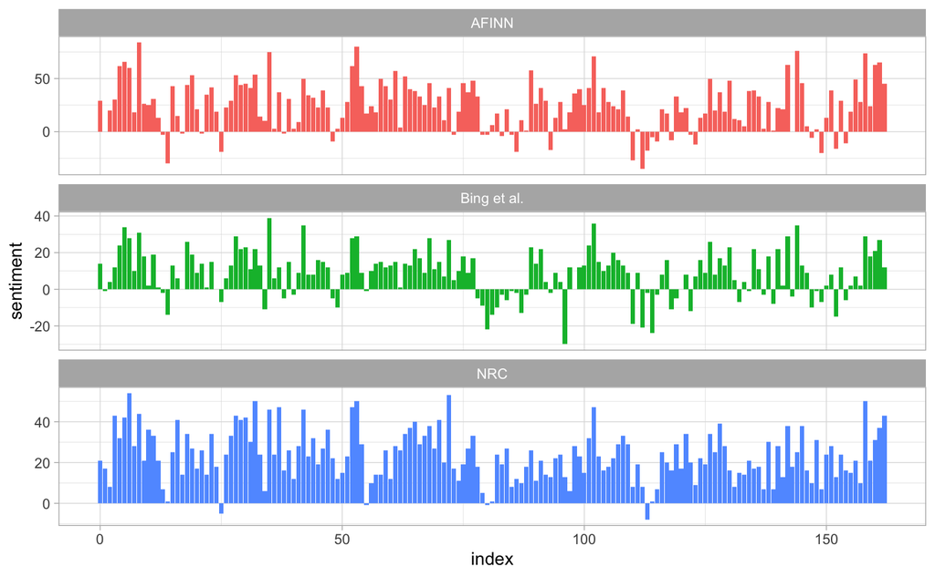

```r
pride_prejudice <- tidy_books %>%
    filter(book == "Pride & Prejudice")

afinn <- pride_prejudice %>%
    inner_join(get_sentiments("afinn"), by = "word") %>%
    group_by(index = linenumber %/% 80) %>%
    summarise(sentiment = sum(value)) %>%
    mutate(method = "AFINN")

bing_and_nrc <- bind_rows(
    pride_prejudice %>%
        inner_join(get_sentiments("bing"), by = "word") %>%
        mutate(method = "Bing et al."),
    pride_prejudice %>%
        inner_join(get_sentiments("nrc") %>%
                       filter(sentiment %in% c(
                           "positive",
                           "negative"
                       )), by = "word") %>%
        mutate(method = "NRC")
) %>%
    count(method, index = linenumber %/% 80, sentiment) %>%
    pivot_wider(names_from = sentiment,
                values_from = n,
                values_fill = 0) %>%
    mutate(sentiment = positive - negative)

bind_rows(afinn,
          bing_and_nrc) %>%
    ggplot(aes(index, sentiment, fill = method)) +
    geom_col(show.legend = FALSE) +
    facet_wrap( ~ method, ncol = 1, scales = "free_y") +
    theme_light()
```

There is some variation - especially in scale - however, the general trend of sentiment through times seems to be similar across the lexicons.

To see what drives some of the variation, we can look at `positive` versus `negative` frequency for the lexicons that have a binary coding - `bing` and `nrc`.

```r
get_sentiments("nrc") %>%
    filter(sentiment %in% c("positive", "negative")) %>%
    count(sentiment) %>%
    kable()
```

| sentiment | n |
| --- | --- |
| negative | 3324 |
| positive | 2312 |

```r
get_sentiments("bing") %>%
    count(sentiment) %>%
    kable()
```

| sentiment | n |
| --- | --- |
| negative | 4781 |
| positive | 2005 |

```r
comp_nrc_bing <- get_sentiments("nrc") %>%
    filter(sentiment %in% c("positive", "negative")) %>%
    inner_join(get_sentiments("bing"), by = "word") %>%
    transmute(word = word, nrc = sentiment.x, bing = sentiment.y)

table(comp_nrc_bing$nrc, comp_nrc_bing$bing, dnn = c("nrc", "bing")) %>%
    kable()
```

|  | negative | positive |
| --- | --- | --- |
| negative | 1675 | 21 |
| positive | 19 | 681 |

Both have more negatives than positives, but the ratio of negative to positive is higher in `bing` - which also has more words categorized on positive / negative sentiment. This contributes to the `nrc` scores being generally higher than the `bing` scores on similar texts.

Note, however, that in the cases where they do match on words, they tend to agree on the sentiment as seen in the bottom table.

## Most common positive and negative words

Another aspet that we can investigate is the impact that any word had on the overall sentiment. Here we show that in the following table and plots.

```r
bing_word_counts <- tidy_books %>%
    inner_join(get_sentiments("bing"), by = "word") %>%
    count(word, sentiment, sort = TRUE) %>%
    ungroup()

kable(bing_word_counts[1:15, ])
```

| word | sentiment | n |
| --- | --- | --- |
| miss | negative | 1855 |
| well | positive | 1523 |
| good | positive | 1380 |
| great | positive | 981 |
| like | positive | 725 |
| better | positive | 639 |
| enough | positive | 613 |
| happy | positive | 534 |
| love | positive | 495 |
| pleasure | positive | 462 |
| poor | negative | 424 |
| happiness | positive | 369 |
| right | positive | 329 |
| best | positive | 323 |
| comfort | positive | 292 |

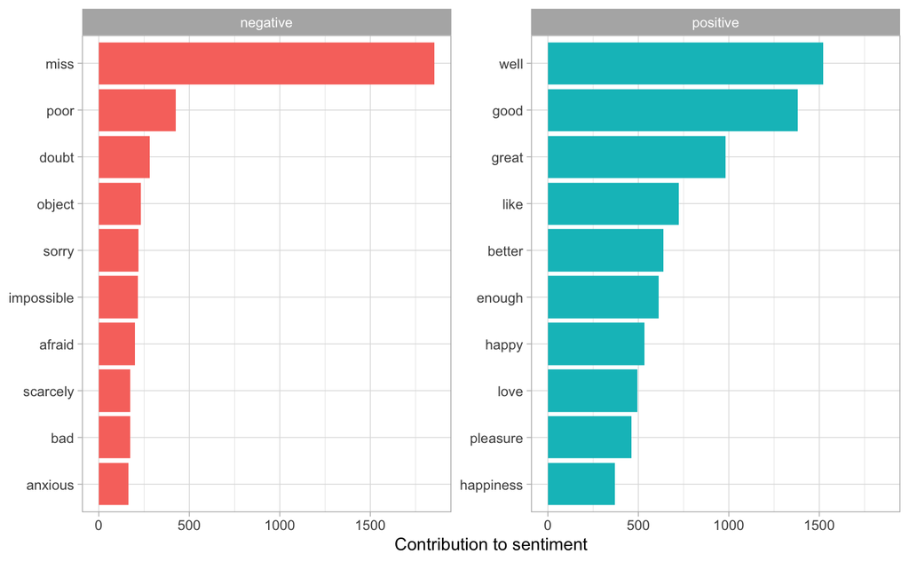

```r
bing_word_counts %>%
    group_by(sentiment) %>%
    slice_max(n, n = 10) %>%
    ungroup() %>%
    mutate(word = reorder(word, n)) %>%
    ggplot(aes(n, word, fill = sentiment)) +
    geom_col(show.legend = FALSE) +
    facet_wrap( ~ sentiment, scales = "free_y") +
    labs(x = "Contribution to sentiment",
         y = NULL) +
    theme_light()
```

This does show a potential anomaly with the word ‘miss’ - which is coded as negative sentiment. If the meaning in the text is a reference to a young woman, that would not necessarily be correct.

One way to handle this is with a custom stop words list.

```r
custom_stop_words <- bind_rows(tibble(word = c("miss"),
                                      lexicon = c("custom")),
                               stop_words)

kable(custom_stop_words[1:10, ])
```

| word | lexicon |
| --- | --- |
| miss | custom |
| a | SMART |
| a’s | SMART |
| able | SMART |
| about | SMART |
| above | SMART |
| according | SMART |
| accordingly | SMART |
| across | SMART |
| actually | SMART |

## Wordclouds

Here we review some alternative graphic views from those used already (i.e., `ggplot`).

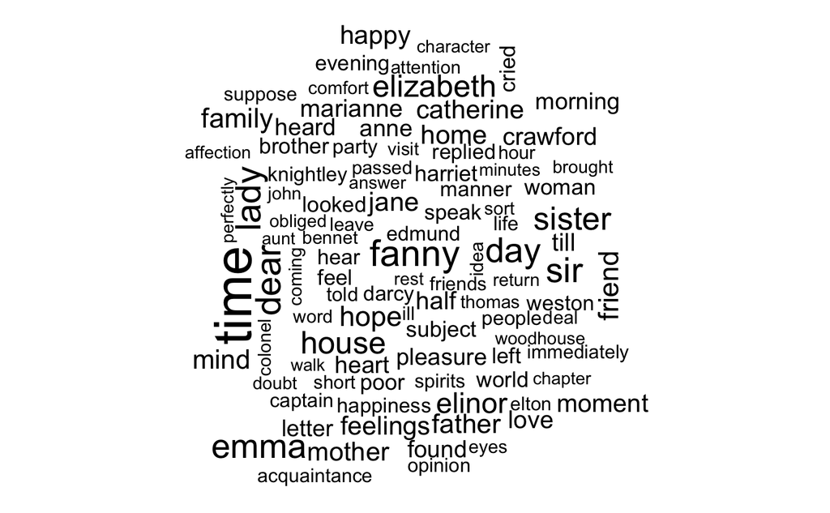

The most common words in Jane Austen’s novels - Wordcloud view

```r
tidy_books %>%
  anti_join(stop_words, by = "word") %>%
  count(word) %>%
  with(wordcloud(word, n, max.words = 100))
```

Some functions require a matrix. The package `reshape2` provides the function `acast()` to do this. Then we can use `comparison.cloud()` to see a Wordcloud segragated by positive and negative.

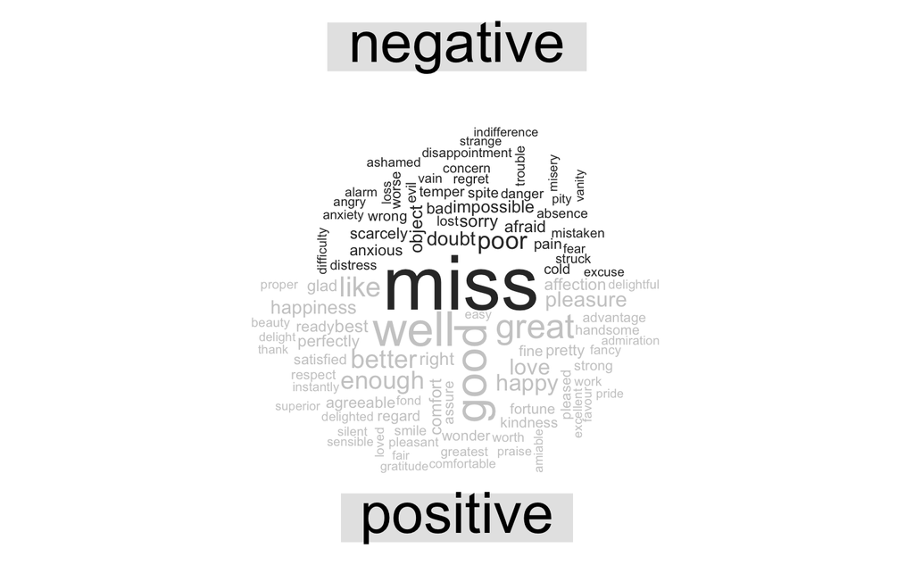

The most common positive versus negative words in Jane Austen’s novels - Wordcloud view

```r
tidy_books %>%
    inner_join(get_sentiments("bing"), by = "word") %>%
    count(word, sentiment, sort = TRUE) %>%
    acast(word ~ sentiment, value.var = "n", fill = 0) %>%
    comparison.cloud(colors = c("gray20", "gray80"),
                     max.words = 100)
```

## Looking at units beyond just words

Here we investigate tokenizing text a levels larger than single words.

```r
p_and_p_sentences <- tibble(text = prideprejudice) %>%
    unnest_tokens(sentence, text, token = "sentences")

kable(p_and_p_sentences[1:10,])
```

| sentence |
| --- |
| pride and prejudice |
| by jane austen |
| chapter 1 |
| it is a truth universally acknowledged, that a single man in possession |
| of a good fortune, must be in want of a wife. |
| however little known the feelings or views of such a man may be on his |
| first entering a neighbourhood, this truth is so well fixed in the minds |
| of the surrounding families, that he is considered the rightful property |
| of some one or other of their daughters. |
| "my dear mr. |

We see that the tokenizing algorithm does have some trouble with the text encoding. One solution is to try changing the encoding.

```r
p_and_p_sentences <- tibble(text = prideprejudice) %>%
    mutate(text = iconv(text, to = 'latin1')) %>%
    unnest_tokens(sentence, text, token = "sentences")

kable(p_and_p_sentences[1:10,])
```

| sentence |
| --- |
| pride and prejudice |
| by jane austen |
| chapter 1 |
| it is a truth universally acknowledged, that a single man in possession |
| of a good fortune, must be in want of a wife. |
| however little known the feelings or views of such a man may be on his |
| first entering a neighbourhood, this truth is so well fixed in the minds |
| of the surrounding families, that he is considered the rightful property |
| of some one or other of their daughters. |
| "my dear mr. |

But we see in this case that it doesn’t really help.

Another option is to use a regular expression to tokenize the text - for instance chapters in a book.

```r
austen_chapters <- austen_books() %>%
    group_by(book) %>%
    unnest_tokens(chapter, text, token = "regex",
                  pattern = "Chapter|CHAPTER [\\dIVXLC]") %>%
    ungroup()

austen_chapters %>%
    group_by(book) %>%
    summarise(chapters = n()) %>%
    kable()
```

| book | chapters |
| --- | --- |
| Sense & Sensibility | 51 |
| Pride & Prejudice | 62 |
| Mansfield Park | 49 |
| Emma | 56 |
| Northanger Abbey | 32 |
| Persuasion | 25 |

Then, for instance, we can look at sentiment by chapter. The following finds the chapter in each Jane Austen book with the highest negative word ratio in the book.

```r
bingnegative <- get_sentiments("bing") %>%
    filter(sentiment == "negative")

wordcounts <- tidy_books %>%
    group_by(book, chapter) %>%
    summarize(words = n())

tidy_books %>%
    semi_join(bingnegative) %>%
    group_by(book, chapter) %>%
    summarize(negativewords = n()) %>%
    left_join(wordcounts, by = c("book", "chapter")) %>%
    mutate(pct_neg = round(100 * negativewords / words, 2)) %>%
    filter(chapter != 0) %>%
    slice_max(pct_neg, n = 1) %>%
    ungroup() %>%
    kable()
```

| book | chapter | negativewords | words | pct_neg |
| --- | --- | --- | --- | --- |
| Sense & Sensibility | 43 | 161 | 3405 | 4.73 |
| Pride & Prejudice | 34 | 111 | 2104 | 5.28 |
| Mansfield Park | 46 | 173 | 3685 | 4.69 |
| Emma | 15 | 151 | 3340 | 4.52 |
| Northanger Abbey | 21 | 149 | 2982 | 5.00 |
| Persuasion | 4 | 62 | 1807 | 3.43 |